# LM sheet 2

salary.dat uploaded on Blackboard has some data on the salaries of n = 52 faculty in a small college in US. An issue is the extent to which women are paid less than men in comparable positions.

The data frame contains sx (gender, two levels: female, male), rk (rank, three levels: assistant, associate, full), yr (years at rank, numeric), dg (highest degree, two levels: doctorate, masters), yd (years since degree, numeric) and sl (salary, numeric) which serves as the response.

```r
library(dplyr)
salary <- read.table(file="C:/Users/Dom/Documents/GitHub/Stats Work/Year 3/Linear Models/salary.dat", header=TRUE) #read in data in .dat format
head(salary) #view first six entries of salary
```

|  | sx | rk | yr | dg | yd | sl |
| --- | --- | --- | --- | --- | --- | --- |
| 1 | male | full | 25 | doctorate | 35 | 36350 |
| 2 | male | full | 13 | doctorate | 22 | 35350 |
| 3 | male | full | 10 | doctorate | 23 | 28200 |
| 4 | female | full | 7 | doctorate | 27 | 26775 |
| 5 | male | full | 19 | masters | 30 | 33696 |
| 6 | male | full | 16 | doctorate | 21 | 28516 |

“Regress salary on sx and interpret the resulting coefficients. Is there evidence of gender discrimination?”

```r
lm( salary$sl ~ salary$sx) #model relationship between salary and sex
```

```
Call:
lm(formula = salary$sl ~ salary$sx)

Coefficients:
  (Intercept)  salary$sxmale
        21357           3340
```

This cursory analysis indicates that the expected difference between male and female employees is $3340, though there are more factors in play.

////

“Before drawing conclusions, we should control for differences in qualifications and experience. One might be tempted to control for rank and years at rank, but what if there is discrimination in promotion? A better approach is to control for highest degree and years since the degree was earned. We also add an interaction between these two variables to allow possibly higher salary for PhD holders with experience. Fit a model with these predictors and interpret all coefficients starting with the constant. Is there evidence of discrimination in salaries when you adjust for degree and years since degree? Did we need the interaction term?”

```r
model <- lm(salary$sl ~ salary$sx + salary$dg + salary$yd + salary$dg*salary$yd) #fit model of salary against sex, degree, years since degree and a mixed effect
model
```

```
Call:
lm(formula = salary$sl ~ salary$sx + salary$dg + salary$yd +
    salary$dg * salary$yd)

Coefficients:
               (Intercept)               salary$sxmale
                   14526.8                      1809.7
          salary$dgmasters                   salary$yd
                    4423.1                       612.8
salary$dgmasters:salary$yd
                    -437.5
```

This leaves us, after controlling for these variables, with a $1809.70 premium for being male.

////

“Compute the jack-knifed residuals and plot them against the fitted values. You may do so manually or use existing R functions by searching for the relevant ones. What does the plot indicate? Comment on any observations with jack-knifed residuals exceeding two in absolute value. Can you formally consider them outliers?”

```r
jkres <- rstudent(model) #calculate jack-knifed residuals for model
plot(model$fitted.values, jkres) #plot jack-knifed residuals against fitted values
abline(a=2,b=0)
```

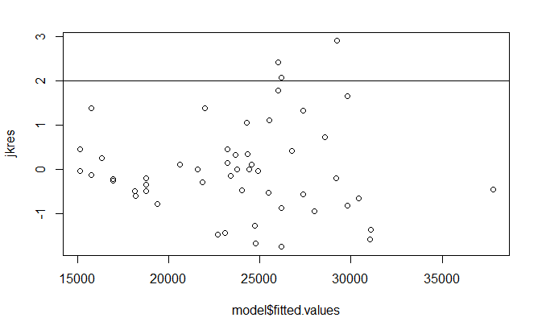

```r
abline(a=-2,b=0) #add lines at significance cutoff
```

These appear to be uniform around 0, meaning the model meets the assumption of linearity. There are 3 observations for which he magnitude of the residual is greater than 2, meaning considering the model without them changes the estimator of the corresponding parameter to a large degree. To formally decide if these are significant outliers, I would perform a hypothesis test on the jack-knifed results with the t distribution.

////

“Compute the leverages and Cook’s distances. Again, you may compute them manually or use existing R functions. List any observations that have high leverage (exceeding 2p/n). Did their leverage translate into actual influence? Find the observation with the largest Cook’s distance. Does it exceed the usual rule of thumb that considers influence excessive when it exceeds one? Would removing this observation affect the results?”

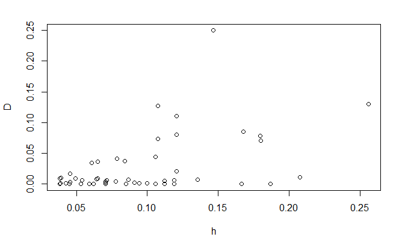

```r
#X <- cbind(1,salary$sx,salary$dg,salary$yd,salary$dg*salary$yd) #assign design matrix X
h <- hatvalues(model) #influence
D <- cooks.distance(model) #cook's distance
plot(h, D)
```

```r
max(D) #return greatest cook's distance
```

```
[1] 0.2501537
```

```r
which(D == max(D)) #find which observation has the greatest
```

```
24
24
```

I can see that no single observation has a Cook’s distance greater than 0.5, so none are problematic or exert actual undue influence.

////

“One way to depict gender differences adjusted for qualifications and experience is to use the regression equation of (c) in order to combine dg and yd into a single measure of qualifications and experience, say dy, adopting their regression coefficients as weights. Plot sl versus dy using different symbols for males and females.”

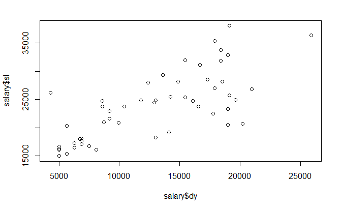